# Homework 1

Shaina Trevino & JP

January 24, 2019

## Creating new visualizations through joins

#### *An exploration of Kaggle’s open university learning analytics dataset*

### Background

For this homework we will use data from the online data science platform [kaggle](https://www.kaggle.com/). Kaggle is an online data science platform that began as a competitive platform for predictive modeling problems. Private organizations would offer a prize, usually in the range of $25K-$100K, for the individual or team that could provide the best predictive model for their problem. This is still a primary function of the website (see active competitions [here](https://www.kaggle.com/competitions%3E)), but the website has grown and is now also a place to share datasets, compete in open competitions (where you can see others code), and generally learn different facets and approaches to data science in an applied way.

#### Getting Started

You can download the data we’ll use for this homework either from kaggle (requires you create an account with [kaggle](https://www.kaggle.com/rocki37/open-university-learning-analytics-dataset)) or [directly from the organization](https://analyse.kmi.open.ac.uk/open_dataset). The latter link is worth examining to learn more about the data, regardless.

A total of seven datasets (tables) related to an online learning analytics project should be included with your download. A number of keys link the various sources of data. I recommend reading through the documentation provided by the organization to better understand these keys.

```r
student <- import(here("data", "studentInfo.csv"),
                  setclass = "tbl_df")

assessment <- import(here("data", "studentAssessment.csv"),
                          setclass = "tbl_df")

as_d <- import(here("data", "assessments.csv"),
               setclass = "tbl_df")
```

### Assignment

This primary components of this assignment are highly open-ended. These are to

1. Use at least 3 mutating joins

```r
j_as_d <- right_join(assessment, as_d, by = "id_assessment") %>%
  group_by(id_student, id_assessment) %>%
  arrange(id_student)
```

```r
key_comp <- right_join(j_as_d, student) %>%
  arrange(id_student)
```

```r
av_score <- key_comp %>%
  group_by(id_student) %>%
  summarize(av_score = mean(score)) %>%
  arrange(desc(av_score))

full <- full_join(av_score, key_comp, by = "id_student")
```

2. Use at least 1 filtering join

```r
fj_d <- key_comp %>%
  group_by(id_student, id_assessment, code_module) %>%
  summarize(avg_score = mean(score, na.rm = TRUE))

fj_d_low <- fj_d %>%
  ungroup() %>%
  filter(avg_score < (mean(avg_score, na.rm = TRUE) - 2*sd(avg_score, na.rm = TRUE)))
fj_d_low
```

```
## # A tibble: 7,265 x 4
##    id_student id_assessment code_module avg_score
##         <int>         <int> <chr>           <dbl>
##  1      24734          1759 AAA                38
##  2      25572         25363 DDD                30
##  3      26315         15020 BBB                 1
##  4      27189         34888 FFF                16
##  5      27189         34889 FFF                35
##  6      27417         25351 DDD                 6
##  7      28046         25353 DDD                24
##  8      28418         24286 CCC                30
##  9      28418         24287 CCC                33
## 10      28787         24298 CCC                21
## # ... with 7,255 more rows
```

```r
semi_fj_d <- semi_join(fj_d, fj_d_low)
semi_fj_d
```

```
## # A tibble: 7,265 x 4
## # Groups:   id_student, id_assessment [?]
##    id_student id_assessment code_module avg_score
##         <int>         <int> <chr>           <dbl>
##  1      24734          1759 AAA                38
##  2      25572         25363 DDD                30
##  3      26315         15020 BBB                 1
##  4      27189         34888 FFF                16
##  5      27189         34889 FFF                35
##  6      27417         25351 DDD                 6
##  7      28046         25353 DDD                24
##  8      28418         24286 CCC                30
##  9      28418         24287 CCC                33
## 10      28787         24298 CCC                21
## # ... with 7,255 more rows
```

3. Produce at least 3 data displays

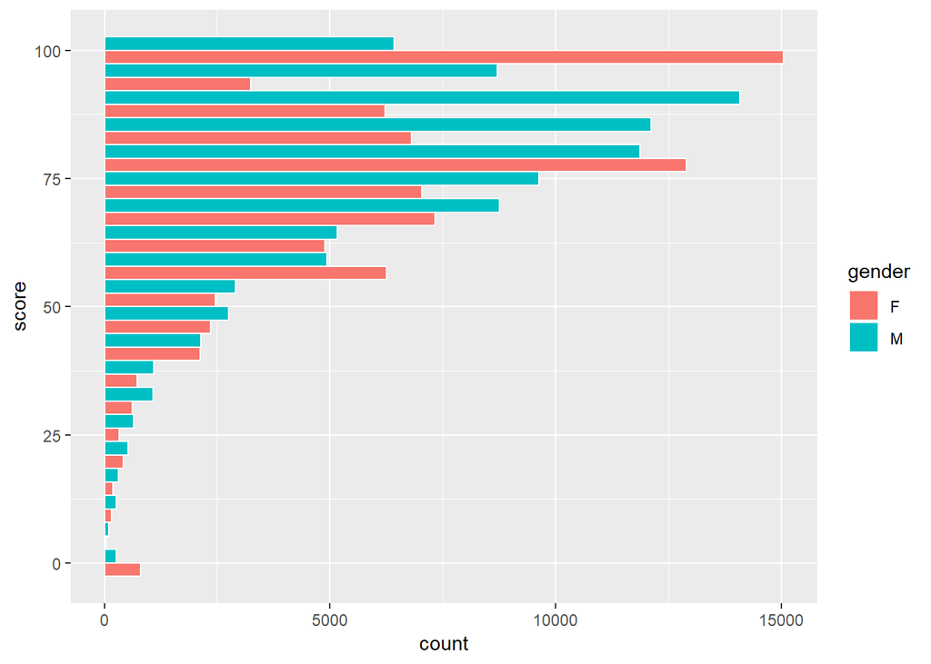

```r
ggplot(full, aes(x = score)) +
  geom_histogram(color = "white",
                 aes(fill = gender),
                 position = "dodge",
                 bins = 20) +
  coord_flip()
```

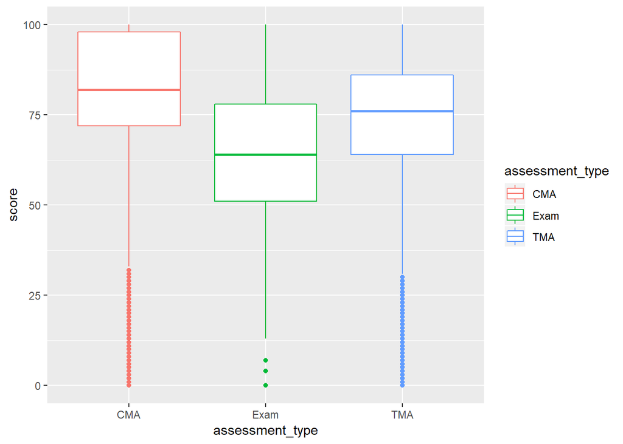

```r
full <- full %>%
  mutate(assessment_type = recode(assessment_type, 'CMA' = 'CMA',
                                  'Exam' = 'Exam',
                                  'TMA' = 'TMA')) %>%
  na.omit()

full %>%
  ggplot(aes(x = assessment_type,
             y = score, color = assessment_type)) +
  geom_boxplot()
```

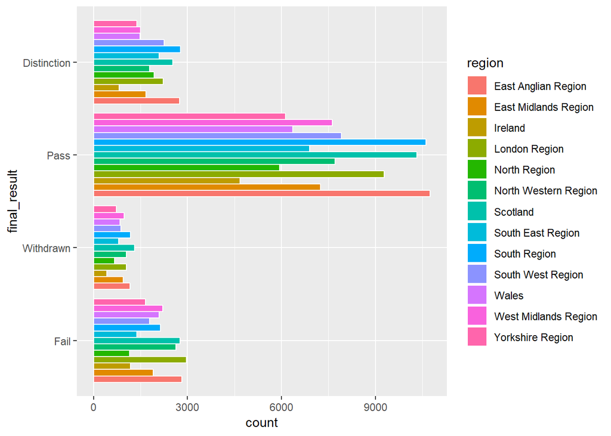

```r
ggplot(full, aes(x = final_result,
                 fill = region)) +
  geom_bar(color = "white",
           position = "dodge") +
  coord_flip()
```

Following the completion of these requirements, please reproduce the following figure.

```r
pd <- key_comp %>% filter(assessment_type == "TMA") %>%
  group_by(gender, final_result, highest_education) %>%
  summarize(av_score = mean(score, na.rm = TRUE)) %>%
  mutate(highest_education = fct_reorder(highest_education, av_score))
```

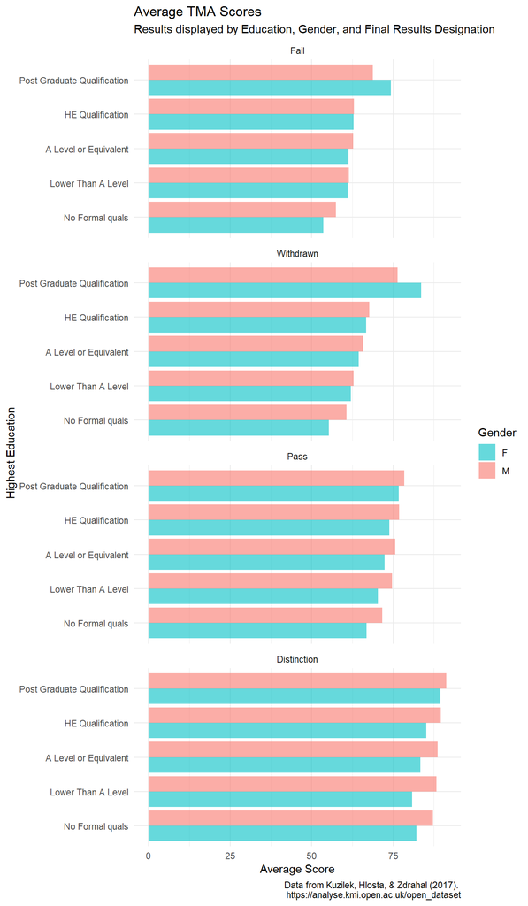

```r
ggplot(pd, aes(x = fct_relevel(highest_education,"No Formal quals",
                               "Lower Than A Level",
                               "A Level or Equivalent",
                               "HE Qualification",
                               "Post Graduate Qualification"), y = av_score)) +
  geom_col(aes(fill = gender), position = "dodge", alpha = .6) +
  scale_fill_manual(values = c("#00BFC4", "#F8766D")) +
  facet_wrap(~ final_result, ncol = 1, strip.position = "top") +
  coord_flip() +
  theme_minimal() +
  labs(title = "Average TMA Scores",
       subtitle = "Results displayed by Education, Gender, and Final Results Designation",
       x = "Highest Education",
       y = "Average Score",
       caption = "Data from Kuzilek, Hlosta, & Zdrahal (2017).
       https://analyse.kmi.open.ac.uk/open_dataset",
       fill = "Gender")
```